# About.Rmd

Katherine Wang

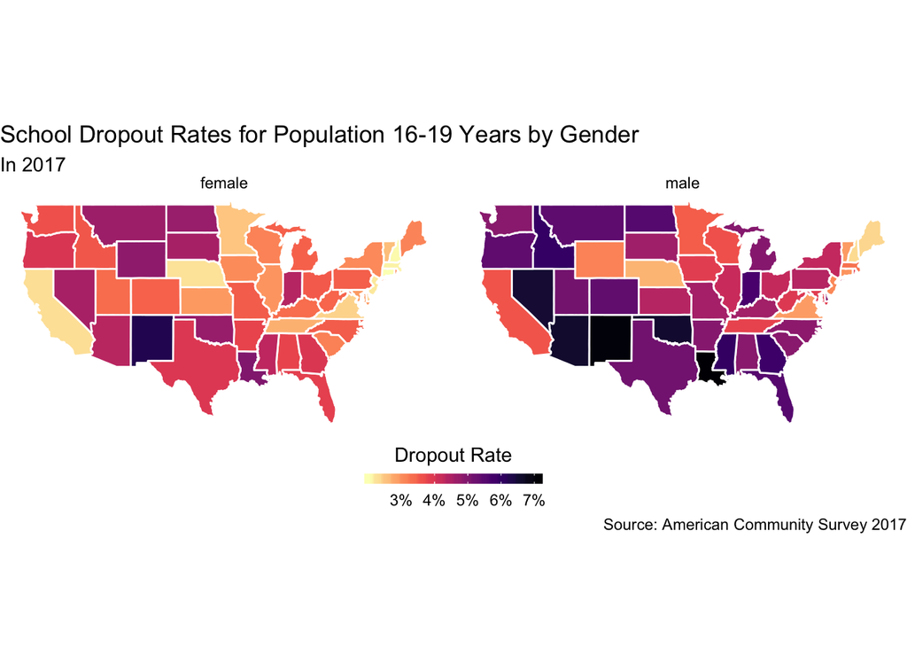

```
## nframes and fps adjusted to match transition
```

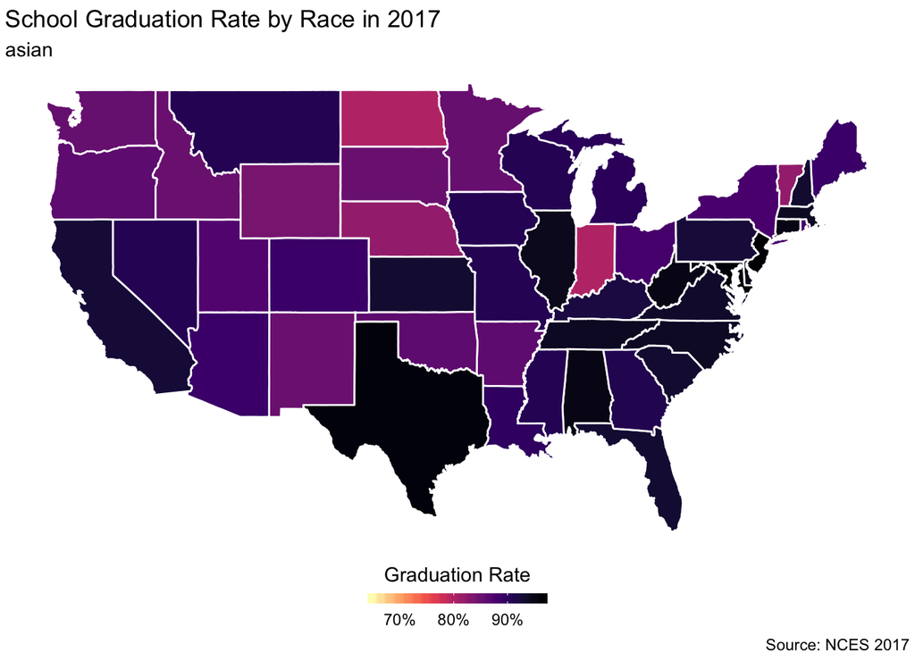

**Background**

The goal of this project is to discover the extent to which a school’s inequality mirrors that of its community’s. Although some believe that schools act as the springboard of social equality and progress, others argue that schools merely reinforce the existing stratification found in their societies. In order to test the idea of whether schools serve as social mirrors, I will analyze two main forms of inequality, race and gender, in two separate spheres – the school and the community. Ultimately, I hope to discover whether a correlative relationship exists between inequality in a community and inequality in schools.

I gathered my data from three sources: the American Community Surveys (ACS) from the US Census Bureau, the National Center for Education Statistics (NCES), and the Status of Women in the States. From ACS’ data, I extracted information about each state’s school dropout rates by gender and average household income by race. The dropout rates correspond to a school’s gender inequality, whereas the household income by race measures a community’s racial inequality. From the data from the National Center for Education Statistics (NCES), I retrieved the adjusted cohort graduation rate (ACGR) based on race, which measures a school’s racial inequality. Finally, from the Status of Women in the States, I obtained data on the gender earnings ratio among the states, which measures a community’s gender inequality.

Url to my repo: https://github.com/katherinewang122/Final-Project-Milestone-5